# Intro to R for IDM : R fundamentals

# 9 Plotting

Base R’s `plot()` function is versatile; you can often get a quick look at your data easily. Plot has a lot of methods which R chooses from depending on the data you give it, to produce a suitable plot. There are also base functions such as `boxplot` which can be quick and easy.

## 9.1 ggplot

A powerful system for visualising data.

- makes you think about the structure and the meaning of your data in order to visualise it
- the syntax is very different to base plotting functions

You create a ggplot object, and then add layers with whatever *aes*thetics you require.

To learn about ggplot, go here: http://r-statistics.co/ggplot2-Tutorial-With-R.html - a nice tutorial, which we will not simply rewrite here! A note: early on, that tutorial says to state what dataframe to use first. This is not necessary; each layer of a ggplot can be drawn from different dataframes, using a `data =` argument. But you should think carefully about your data if you are doing this!

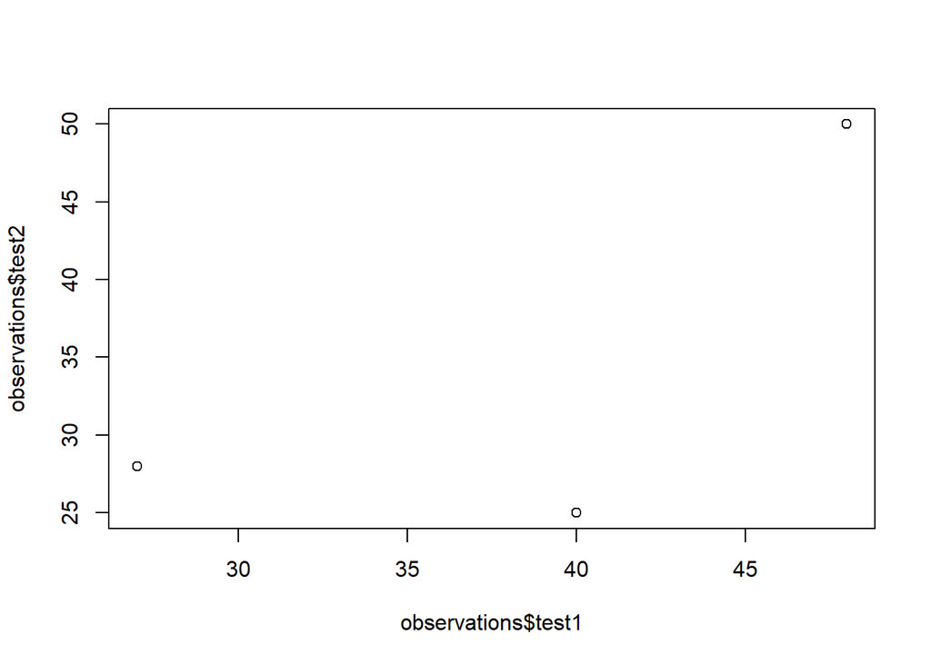

```r
require(ggplot2)
# have a quick look at what these do.

# examples of basic, base plots
plot(observations$test1, observations$test2)
```

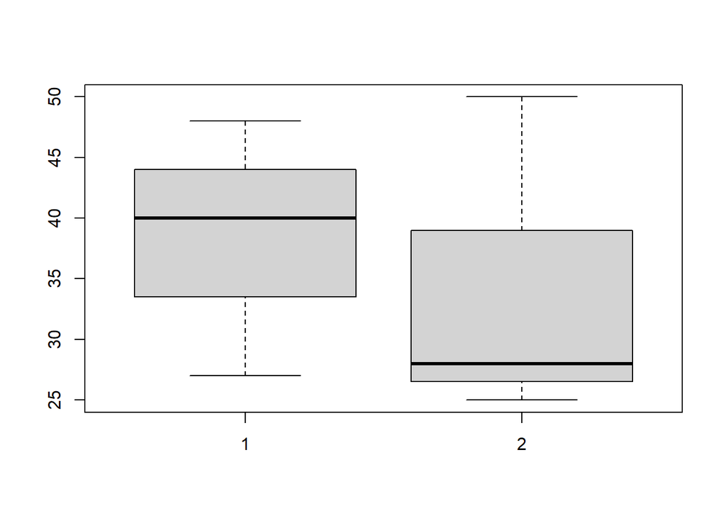

```r
boxplot(observations$test1, observations$test2)
```

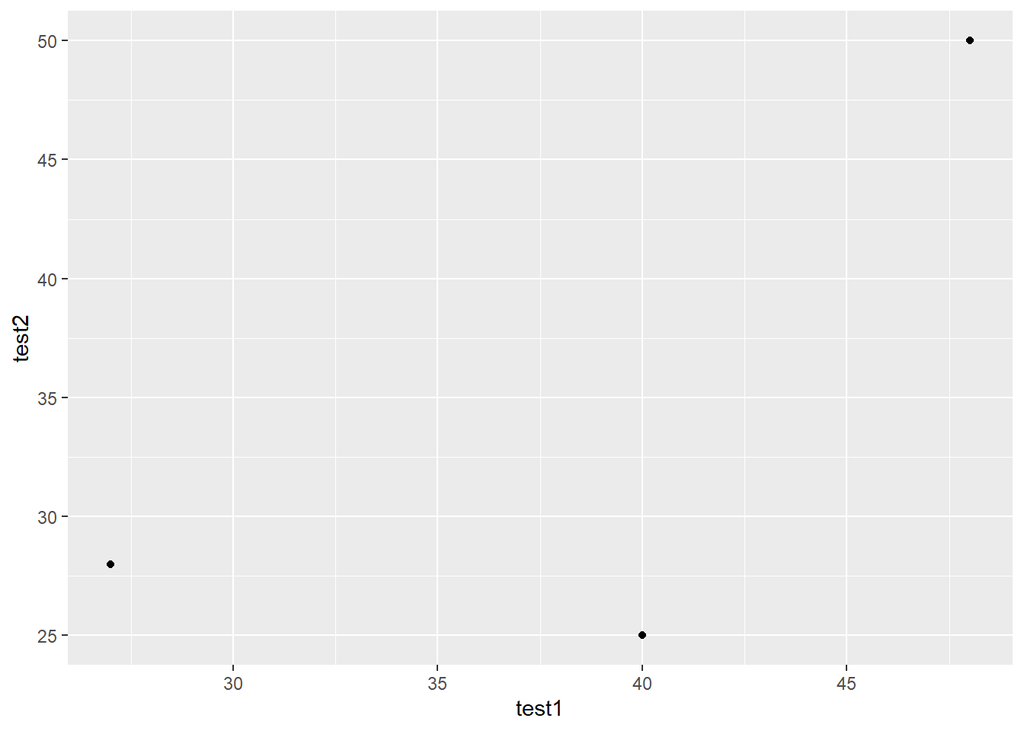

```r
# ggplot
patient_plot <- ggplot(data = observations)
patient_plot <- patient_plot + geom_point(aes(x = test1, y = test2))
patient_plot
```

## 9.2 tidyverse

To learn about tidyverse, go here, (https://www.linkedin.com/learning/learning-the-r-tidyverse/what-is-the-tidyverse - a nice tutorial, which we will not simply rewrite here!

# 10 Finding general help and resources

**within R**:

- `?functionname` to get the help file for a function
  - parts of the help file also show up automatically in RStudio when you type functions
- When you get error messages - search for them on the internet if you can’t work out what’s wrong

**on the internet** :

- General guides - RStudio website https://www.rstudio.com/online-learning/#r-programming has plenty of links and suggestions for R programming and related subjects.
- https://cran.r-project.org/
  - manuals for packages
  - **vignettes** - useful examples
  - e.g. for deSolve: https://cran.r-project.org/web/packages/deSolve/index.html
- Books (free, online)
  - https://adv-r.hadley.nz/ : Advanced R, Hadley Wickham (Second edition) The title is “advanced R”, but it starts off with a solid guide to fundamentals
  - https://r4ds.had.co.nz/ : R for data science, Hadley Wickham
- ggplot help
  - http://r-statistics.co/ggplot2-Tutorial-With-R.html - a nice tutorial
- **R language definitions**: the official explanation of R
  - https://cran.r-project.org/doc/manuals/r-release/R-lang.html#Introduction
- Q & A sites: such as https://stackoverflow.com/

Bear in mind that R, and even more so certain packages, change fast! Often, someone else will be writing something to solve an issue that you’ve been having, and the next time you look for help, you might find something new. This also means when you search the internet for help, you should check whether what you find is still valid.